# DEM manipulation and GIS workflow

## 5. Perform the transformation to **Lecode** input format

In this step we will generate the topographic and initial deposit files for **Lecode** simulation based on the clipped and rotated area.  
First we create an ASCII grid that will be used during the export process. Then `lecode_basic_input` script will create the required **Lecode** files.

```
lecode_basic_input name_ascii_grid thickness_init_layer nb_material_type init_layer_hardness
```

The script requires 3 parameters and an optional one:

- `name_ascii_grid` name of the ASCII grid generated using `gdal_translate`
- `thickness_init_layer` thickness of the initial sedimentary layer in metres,
- `nb_material_type` number of sediments that will be defined in **Lecode** [XmL input file](http://lecode-model.github.io/SGFM/input.html),
- `init_layer_hardness` is optional (default is 1) and enable the definition of a hardness value for basement sedimentary layer.

```python
import os, sys

# Create an ASCII grid from the regular grid obtained using Fatiando library
'''
Use the csv_2_asc script to perform format transformation:
        - the first argument is the CSV file from Fatiando library
        - second argument is the number of columns (W/E direction)
        - third argument is the number of rows (S/N direction)

The script returns a file with the same name as the input file but with the asc extension
'''
os.system('csv_2_asc ../SGFM-data/srtm_63_18/dem_reg.csv 401 501')


"""
Perform the transformation to LECODE input format using lecode_basic_input script
     - first argument is the ASCII grid you've just generated
     - second argument is the thickness of the initial sedimentary layer
     - third argument is the number of sediment classes (they will be distribute evenly over the sedimentary layer)
     - last argument is the layer hardness
"""
os.system('lecode_basic_input ../SGFM-data/srtm_63_18/dem_reg.asc 50 5 10')
print "LECODE input have been created, check for .nodes & .dep files"
```

```
LECODE input have been created, check for .nodes & .dep files
```

## 6. Analyse DEM for better definition of Lecode XmL input parameters

### DEM relief

To have a look at the elevation range you can use `gdalinfo` command with the `mm` option and search within the answer for `Computed Min/Max`.  
Then use the `gdaldem` function with the `color-relief` option.  
Base on the range you can define a text color scale file (some predefined color scales are proposed in the `color-scale` Dropbox folder) to produce a PNG file of the clipped region.

```
Input file size is 401, 501
0...10...20...30...40...50...60...70...80...90...100 - done.
Driver: GTiff/GeoTIFF
Files: ../SGFM-data/srtm_63_18/demrelief.tif
Size is 401, 501
Coordinate System is `'
Origin = (754980.000000000000000,-3050710.000000000000000)
Pixel Size = (200.000000000000000,-200.000000000000000)
Image Structure Metadata:
  INTERLEAVE=BAND
Corner Coordinates:
Upper Left  (  754980.000,-3050710.000)
Lower Left  (  754980.000,-3150910.000)
Upper Right (  835180.000,-3050710.000)
Lower Right (  835180.000,-3150910.000)
Center      (  795080.000,-3100810.000)
Band 1 Block=401x5 Type=Float32, ColorInterp=Gray
    Computed Min/Max=238.834,498.472
0...10...20...30...40...50...60...70...80...90...100 - done.
```

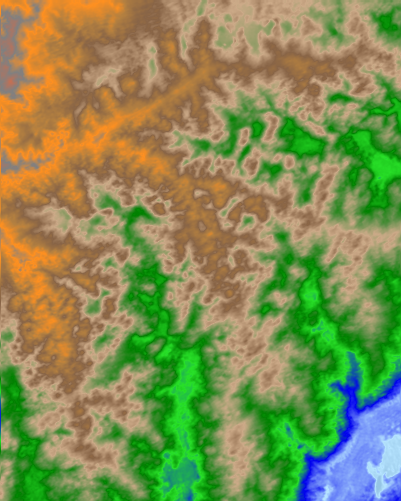

```python
from IPython.core.display import Image

# Transform the ASCII Grid to a Geotiff
!gdal_translate -of "GTiff" ../SGFM-data/srtm_63_18/dem_reg.asc ../SGFM-data/srtm_63_18/demrelief.tif

# Find information about min/max elevation using "-mm" option
!gdalinfo -mm ../SGFM-data/srtm_63_18/demrelief.tif

# Based on elevation extent use an appropriate color scale to create the DEM map
!gdaldem color-relief ../SGFM-data/srtm_63_18/demrelief.tif \
../SGFM-data/color-scale/color_ramp.txt \
../SGFM-data/srtm_63_18/region.png -of PNG

# Show the relief map
Image(filename='../SGFM-data/srtm_63_18/region.png')
```

### DEM slope

To produce the DEM slope we use *gdaldem* function again with *slope* option and the *-p* option as well which specifies that the calculated slope will be expressed as percent slope.  
Again to check the slope range you can use *gdalinfo* function with the `mm` option and search within the output for `Computed Min/Max`.  
Base on the range you can define a text color scale file (some predefined color scales are proposed in the `color-scale` foler for the slope) to produce a PNG file of the clipped region slope.

```
0...10...20...30...40...50...60...70...80...90...100 - done.
Driver: GTiff/GeoTIFF
Files: ../SGFM-data/srtm_63_18/reg_slope_map.tif
Size is 401, 501
Coordinate System is `'
Origin = (754980.000000000000000,-3050710.000000000000000)
Pixel Size = (200.000000000000000,-200.000000000000000)
Image Structure Metadata:
  INTERLEAVE=BAND
Corner Coordinates:
Upper Left  (  754980.000,-3050710.000)
Lower Left  (  754980.000,-3150910.000)
Upper Right (  835180.000,-3050710.000)
Lower Right (  835180.000,-3150910.000)
Center      (  795080.000,-3100810.000)
Band 1 Block=401x5 Type=Float32, ColorInterp=Gray
    Computed Min/Max=0.002,20.163
  NoData Value=-9999
0...10...20...30...40...50...60...70...80...90...100 - done.
```

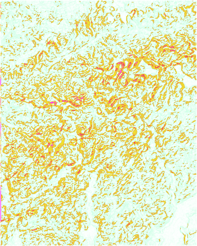

```python
# From a DEM raster, output a 32-bit float raster with slope values (specifies in percent slope)
!gdaldem slope ../SGFM-data/srtm_63_18/demrelief.tif ../SGFM-data/srtm_63_18/reg_slope_map.tif -p

# Find information about min/max slope
!gdalinfo -mm ../SGFM-data/srtm_63_18/reg_slope_map.tif

# Based on elevation extent use an appropriate color scale to create the DEM slope map
!gdaldem color-relief ../SGFM-data/srtm_63_18/reg_slope_map.tif ../SGFM-data/color-scale/color_slope2.txt \
../SGFM-data/srtm_63_18/reg_slope_map.png -of PNG

# Show the slope map
Image(filename='../SGFM-data/srtm_63_18/reg_slope_map.png')
```

### Flow accumulation map

LECODE uses flow accumulation maps to defined several parameters such as the adaptive TIN resolution or to trigger mass movements (see [website](http://lecode-model.github.io/SGFM/overview.html) for more information).  
The next step will create the initial flow accumulation map that could be use to define these parameters in the [XmL input file](http://lecode-model.github.io/SGFM/input.html).

```python
import os, sys

'''
Perform Planchon fill depression algorithm using the fill_depression script
        - first argument is the ASCII grid created in step 5,
        - second argument is the output file name a depressionless ASCII grid.
        - third argument is the parameter used to remove the flat and hole areas.

Ref: Planchon, O., and F., Darboux (2001).
    A fast, simple and versatile algorithm to fill the depressions of digital elevation models.
    Catena, 46, 159–176.
'''
os.system('fill_depression ../SGFM-data/srtm_63_18/dem_reg.asc ../SGFM-data/srtm_63_18/demshape.asc 0.001')

'''
Run the multiple flow direction script flow_acc
        - first argument is the depressionless ASCII grid created above
        - second argument is the flow accumulation ASCII grid.

'''
os.system('flow_acc ../SGFM-data/srtm_63_18/demshape.asc ../SGFM-data/srtm_63_18/facc_reg.asc')

# Transform the MFD flow accumulation map in Geotiff
!gdal_translate -of "GTiff" ../SGFM-data/srtm_63_18/facc_reg.asc ../SGFM-data/srtm_63_18/facc_reg.tif

# Open the flow accumulation file in iPython
gflow = gdal.Open('../SGFM-data/srtm_63_18/facc_reg.tif',GA_ReadOnly)

# Get the flow accumulation range using the -mm option
!gdalinfo -mm ../SGFM-data/srtm_63_18/facc_reg.tif
```

```
Input file size is 401, 501
0...10...20...30...40...50...60...70...80...90...100 - done.
Driver: GTiff/GeoTIFF
Files: ../SGFM-data/srtm_63_18/facc_reg.tif
Size is 401, 501
Coordinate System is `'
Origin = (754980.000000000000000,-3050710.000000000000000)
Pixel Size = (200.000000000000000,-200.000000000000000)
Image Structure Metadata:
  INTERLEAVE=BAND
Corner Coordinates:
Upper Left  (  754980.000,-3050710.000)
Lower Left  (  754980.000,-3150910.000)
Upper Right (  835180.000,-3050710.000)
Lower Right (  835180.000,-3150910.000)
Center      (  795080.000,-3100810.000)
Band 1 Block=401x5 Type=Float32, ColorInterp=Gray
    Computed Min/Max=1.000,59374.699
  NoData Value=448
```

```
0...10...20...30...40...50...60...70...80...90...100 - done.
```

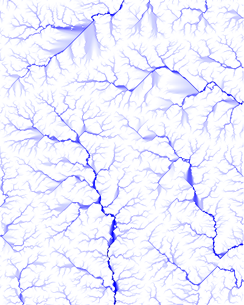

```python
# Based on flow accumulation extent use an appropriate color scale to create the DEM flow accumulation map
!gdaldem color-relief ../SGFM-data/srtm_63_18/facc_reg.tif \
../SGFM-data/color-scale/color_facc2.txt ../SGFM-data/srtm_63_18/facc_reg.png -of PNG

# Show the slope map
Image(filename='../SGFM-data/srtm_63_18/facc_reg.png')
```

The input topographic and deposit files for LECODE have been generated in the Dropbox folder you have been working on.  
You should find in the directory:

- a `.nodes` file containing the simulation area coordinates and basement elevation
- a `.dep` file containing the simulation area initial deposit file

These files are both required to start a simulation and need to be use in conjonction with a XmL input.  
Information to create LECODE XmL input file can be find in the [SGFM website](http://lecode-model.github.io/SGFM/index.html).